# Homework 3

*Ahmet Sualp Say - IE582 - Fall 2021*

```r
require(repr)
options(scipen=999)
options(repr.plot.width=15, repr.plot.height=8)
```

### Task 1 – On the use of distance information for UwaveGesture Recognition Task

Use the UWave data provided in the second homework for this task. In the second homework, you were given only the training data. This task requires performing classification task on the test data and evaluate the performance of certain classifiers. Test data is uploaded as *.zip files for each axis (i.e. X, Y and Z). It has the same format as the training data.

```r
require(data.table)

# assuming you have the XYZ cordinates in your working directory in the following format:
# 'working_directory/'
current_folder = getwd()

file_names = list.files(pattern = "uWaveGestureLibrary")
list_files = lapply(file_names, read.table)

list_files = lapply(seq_along(list_files), function(x) {
  list_files[[x]]$V0 = 1:nrow(list_files[[x]]) # column VO is created to specify the sample instance
  list_files[[x]]
})
```

```r
# 2, 4, 6 are _TRAIN files
x = as.data.table(list_files[2])
x = x[,-317]
colnames(x) = paste0("X", as.numeric(gsub("V", "", colnames(x)))-1)
setnames(x, "X0", "class")

y = as.data.table(list_files[4])
y = y[,-317]
colnames(y) = paste0("Y", as.numeric(gsub("V", "", colnames(y)))-1)
y = y[,-1]

z = as.data.table(list_files[6])
z = z[,-317]
colnames(z) = paste0("Z", as.numeric(gsub("V", "", colnames(z)))-1)
z = z[,-1]

xyz_train = cbind(x, y, z)
xyz_train[, class:=as.factor(class)]
levels(xyz_train$class) <- c("1", "2", "3", "4", "5", "6", "7", "8")

x = as.data.table(list_files[1])
x = x[,-317]
colnames(x) = paste0("X", as.numeric(gsub("V", "", colnames(x)))-1)
setnames(x, "X0", "class")

y = as.data.table(list_files[3])
y = y[,-317]
colnames(y) = paste0("Y", as.numeric(gsub("V", "", colnames(y)))-1)
y = y[,-1]

z = as.data.table(list_files[5])
z = z[,-317]
colnames(z) = paste0("Z", as.numeric(gsub("V", "", colnames(z)))-1)
z = z[,-1]

xyz_test = cbind(x, y, z)
xyz_test[, class:=as.factor(class)]
levels(xyz_test$class) <- c("1", "2", "3", "4", "5", "6", "7", "8")
```

```r
head(xyz_train)
```

| class | X1 | X2 | X3 | X4 | X5 | X6 | X7 | X8 | X9 | ... | Z306 | Z307 | Z308 | Z309 | Z310 | Z311 | Z312 | Z313 | Z314 | Z315 |
| --- | --- | --- | --- | --- | --- | --- | --- | --- | --- | --- | --- | --- | --- | --- | --- | --- | --- | --- | --- | --- |
| 6 | -0.304243210 | -0.304243210 | -0.304243210 | -0.304243210 | -0.304243210 | -0.304243210 | -0.304243210 | -0.304243210 | -0.304243210 | ... | 0.5232168 | 0.5139944 | 0.50348075 | 0.49296714 | 0.47452222 | 0.4560773 | 0.4376324 | 0.4191875 | 0.4007426 | 0.3822976 |
| 5 | 1.627311100 | 1.627311100 | 1.627311100 | 1.627311100 | 1.627311100 | 1.627311100 | 1.627311100 | 1.627311100 | 1.627311100 | ... | -0.4270104 | -0.4270104 | -0.42701043 | -0.42717222 | -0.42877307 | -0.4407199 | -0.4526667 | -0.4646135 | -0.4765603 | -0.4885071 |
| 5 | 0.661276530 | 0.661276530 | 0.661276530 | 0.661276530 | 0.661276530 | 0.661276530 | 0.661276530 | 0.661276530 | 0.661276530 | ... | -0.8627172 | -0.8627172 | -0.86271720 | -0.86271720 | -0.86271720 | -0.8627172 | -0.8627172 | -0.8627172 | -0.8627172 | -0.8627172 |
| 3 | 0.005184784 | 0.005184784 | 0.005184784 | 0.005184784 | 0.005184784 | 0.005184784 | 0.005184784 | 0.005184784 | 0.005184784 | ... | -0.1873845 | -0.1235489 | -0.05587047 | 0.01180812 | 0.07948656 | 0.1570561 | 0.2537396 | 0.4455027 | 0.6485381 | 0.8515735 |
| 4 | 1.286197800 | 1.286197800 | 1.286197800 | 1.286197800 | 1.286197800 | 1.286197800 | 1.286197800 | 1.286197800 | 1.286197800 | ... | 1.8674725 | 1.8343190 | 1.75599960 | 1.63858220 | 1.52116390 | 1.4532661 | 1.5152189 | 1.6326367 | 1.7500543 | 1.8674725 |
| 8 | -0.479252460 | -0.479252460 | -0.479252460 | -0.479252460 | -0.479252460 | -0.479252460 | -0.479252460 | -0.479252460 | -0.479252460 | ... | 0.6979770 | 0.6654623 | 0.63294758 | 0.60043289 | 0.55859021 | 0.5167475 | 0.4679755 | 0.4192035 | 0.3704314 | 0.3216594 |

```r
head(xyz_test)
```

| class | X1 | X2 | X3 | X4 | X5 | X6 | X7 | X8 | X9 | ... | Z306 | Z307 | Z308 | Z309 | Z310 | Z311 | Z312 | Z313 | Z314 | Z315 |
| --- | --- | --- | --- | --- | --- | --- | --- | --- | --- | --- | --- | --- | --- | --- | --- | --- | --- | --- | --- | --- |
| 5 | 1.55701760 | 1.55701760 | 1.55701760 | 1.55701760 | 1.55701760 | 1.55701760 | 1.55701760 | 1.55701760 | 1.55701760 | ... | -0.3484232 | -0.3484232 | -0.3446754 | -0.3407276 | -0.3331472 | -0.3254234 | -0.3176995 | -0.3099757 | -0.30225190 | -0.29452808 |
| 1 | -0.07509626 | -0.07509626 | -0.07509626 | -0.07509626 | -0.07509626 | -0.07509626 | -0.07509626 | -0.07509626 | -0.07509626 | ... | 0.9613500 | 0.8491418 | 0.7255457 | 0.5892767 | 0.5390750 | 0.5158101 | 0.5158101 | 0.5158101 | 0.51581006 | 0.51581006 |
| 4 | 1.50901170 | 1.52629600 | 1.54358030 | 1.56086460 | 1.57381090 | 1.57691320 | 1.57859210 | 1.57859210 | 1.57859210 | ... | -0.5659620 | -0.4756798 | -0.3990893 | -0.3440736 | -0.2890578 | -0.2340421 | -0.1790264 | -0.1240107 | -0.06899497 | -0.01397925 |
| 4 | 1.30397390 | 1.30397390 | 1.30397390 | 1.30397390 | 1.30397390 | 1.30397390 | 1.30397390 | 1.30397390 | 1.30397390 | ... | 1.0449500 | 1.0449500 | 1.0449500 | 1.0449500 | 1.0793386 | 1.1150846 | 1.1710012 | 1.2274418 | 1.28388270 | 1.34032360 |
| 5 | 1.29808900 | 1.29808900 | 1.29808900 | 1.29808900 | 1.29808900 | 1.29808900 | 1.29808900 | 1.29808900 | 1.29808900 | ... | -0.6934601 | -0.6897651 | -0.6860701 | -0.6823750 | -0.6786800 | -0.6749850 | -0.6712899 | -0.6675949 | -0.66389985 | -0.66020482 |
| 4 | 1.01157350 | 1.08170540 | 1.15183720 | 1.22138950 | 1.28030020 | 1.30519210 | 1.30519210 | 1.30519210 | 1.30519210 | ... | 1.5889660 | 1.5889660 | 1.5889660 | 1.5889660 | 1.5889660 | 1.5025310 | 1.2979683 | 1.0564539 | 0.81292720 | 0.56940054 |

```r
train_classes = xyz_train$class
test_classes = xyz_test$class

xyz_train_nn = xyz_train[,2:ncol(xyz_train)]
xyz_test_nn = xyz_test[,2:ncol(xyz_test)]
```

*a) Suppose we decided to apply a nearest-neighbor (NN) classifier to find the labels of test instances. You can use the strategy you employed when you apply PCA to this data in Homework 2 (i.e. concatenation of the axes). Propose two distance measures for computing similarity between two time series. The distance calculation on the concatenated time series implicitly weights the distances of each axis in an equal way. For each distance measure alternative, use the training data to identify the ideal value of k which minimizes the error of a 10-fold cross-validation.*

```r
## Proposed distance measures
# Euclidean distance
# Manhattan distance

# For train set;
# calculate Euclidean distance matrix and store
dist_euc = as.matrix(dist(xyz_train_nn, method="euclidean"))
diag(dist_euc) = 10000
fwrite(dist_euc, "euc_train_dist.csv", col.names=F)

# calculate Manhattan distance matrix and store
dist_mht = as.matrix(dist(xyz_train_nn, method="manhattan"))
diag(dist_mht) = 10000
fwrite(dist_mht, "mht_train_dist.csv", col.names=F)
```

```
x being coerced from class: matrix to data.table
x being coerced from class: matrix to data.table
```

```r
require(TunePareto)

set.seed(2021)
nof_rep = 10
n_fold = 10
# create test indices to be used in cross-validation
cv_indices = generateCVRuns(train_classes, ntimes = nof_rep, nfold = n_fold, leaveOneOut = FALSE, stratified = TRUE)

# function to find nearest neighbours
nn_classify = function(dist_matrix, train_classes, test_indices, k=1){

    test_distances_to_train = dist_matrix[test_indices,]
    test_distances_to_train = test_distances_to_train[,-test_indices]
    train_classes = train_classes[-test_indices]
    # order the distances of each instance to another
    ordered_neighbours = apply(test_distances_to_train, 1, order)
    if(k==1){
        nearest_class = as.numeric(ordered_neighbours[as.numeric(ordered_neighbours[1,])])
        nearest_class = data.table(id=test_indices, nearest_class)
    } else {
        # returns each classes' k nearest neighbours
        nearest_class = apply(ordered_neighbours[1:k,], 2, function(x) {train_classes[x]})
        nearest_class = data.table(id=test_indices, t(nearest_class))
    }

    long_nn_class = melt(nearest_class,'id')

    # count the classes of nearest neighbours for each instance
    class_counts = long_nn_class[,.N,list(id,value)]
    # calculate the frequency of each neigbour
    class_counts[,predicted_prob:=N/k]
    wide_class_prob_predictions = dcast(class_counts, id~value, value.var='predicted_prob')
    wide_class_prob_predictions[is.na(wide_class_prob_predictions)]=0
    # returns class which has higher probability (i.e most frequent class) as predicted value
    class_predictions = class_counts[,list(predicted = value[which.max(N)]), by=list(id)]

    return(list(prediction = class_predictions, prob_estimates = wide_class_prob_predictions))

}
```

```r
dist_files = list.files(pattern = "train_dist")
```

```r
dist_files
```

1. 'euc_train_dist.csv'

2. 'mht_train_dist.csv'

```r
k_levels = c(1:10)
result = vector('list',length(dist_files)*nof_rep*n_fold*length(k_levels))

iter=1
# loop to calculate best k value for nearest neighbour with 10-fold-cross-validation, returns accuracy of each run in each fold
for(m in 1:length(dist_files)){
    dist_mat = as.matrix(fread(dist_files[m], header=FALSE))

    for(i in 1:nof_rep){
        this_fold = cv_indices[[i]]

        for(j in 1:n_fold){
            test_indices = this_fold[[j]]

            for(k in 1:length(k_levels)){
                current_k = k_levels[k]
                current_fold = nn_classify(dist_mat, train_classes, test_indices, k = current_k)
                accuracy = sum(train_classes[test_indices]==current_fold$prediction$predicted)/length(test_indices)
                tmp = data.table(distance_measure = dist_files[m], repid = i, foldid = j, k = current_k, acc = accuracy)
                result[[iter]] = tmp
                iter=iter+1

            }

        }

    }

}
```

```r
overall_results = rbindlist(result)
overall_results[,list(avg_accuracy = mean(acc), sdev_accuracy=sd(acc)), by=list(distance_measure, k)]
```

[output not shown]

###### From the result table above one can see that, for both Euiclidean and Manhattan distance, k=4 seem to be best among other k levels with its average accuracy and standard deviation

*b) Using the value of k (identified for each distance measure) in part (a) and evaluate your final performance on the test data and present your results in a (8-by-8) confusion matrix, showing the counts for actual and predicted labels. In addition, quote the runtime and accuracy for your results.*

```r
# For test set;
# calculate Euclidean distance matrix and store
dist_euc = as.matrix(dist(xyz_test_nn, method="euclidean"))
diag(dist_euc) = 10000
fwrite(dist_euc, "euc_test_dist.csv", col.names=F)

# calculate Manhattan distance matrix and store
dist_mht = as.matrix(dist(xyz_test_nn, method="manhattan"))
diag(dist_mht) = 10000
fwrite(dist_mht, "mht_test_dist.csv", col.names=F)
```

```
x being coerced from class: matrix to data.table
x being coerced from class: matrix to data.table
```

```r
best_k_levels = c(4,4)
dist_files = list.files(pattern = "test_dist")

for(m in 1:length(dist_files)){
    print(dist_files[m])
    dist_mat = as.matrix(fread(dist_files[m], header=FALSE))

    best_k_level_for_current_approach = best_k_levels[m]
    ordered_neighbours = apply(dist_mat, 1, order)
    nearest_class = apply(ordered_neighbours[1:best_k_level_for_current_approach,], 2, function(x) {test_classes[x]})
    nearest_class = data.table(id=1:nrow(dist_mat), t(nearest_class))

    long_nn_class = melt(nearest_class,'id')
    class_counts = long_nn_class[,.N,list(id,value)]
    class_counts[,predicted_prob:=N/best_k_level_for_current_approach]
    wide_class_prob_predictions = dcast(class_counts, id~value, value.var='predicted_prob')
    wide_class_prob_predictions[is.na(wide_class_prob_predictions)]=0
    class_predictions = class_counts[,list(predicted = value[which.max(N)]), by=list(id)]

    # create confusion matrix and report accuracy
    true_status = test_classes
    confusion_matrix = table(true_status, prediction=class_predictions$predicted)
    print(confusion_matrix)

    accuracy = sum(true_status==class_predictions$predicted)/length(class_predictions$predicted)
    print(accuracy)

}
```

```
[1] "euc_test_dist.csv"
           prediction
true_status   1   2   3   4   5   6   7   8
          1 436   0   0   0   0   1   0   0
          2   1 451   0   0   0   0   0   0
          3   0   0 429   0  10  10   5   0
          4   6   0   0 398  38   2   0   6
          5   3   0   6   2 418   4   0   0
          6   6   0   5   8  17 413   0   0
          7   0   0   0   0   0   0 447   0
          8   0   0   0   0   1   0   0 459
[1] 0.9634283
[1] "mht_test_dist.csv"
           prediction
true_status   1   2   3   4   5   6   7   8
          1 435   0   0   0   0   2   0   0
          2   1 451   0   0   0   0   0   0
          3   0   0 436   1   6   6   5   0
          4   2   0   1 406  30   6   0   5
          5   3   0   6   4 419   1   0   0
          6   4   0   6  10  14 415   0   0
          7   0   0   0   0   0   0 447   0
          8   0   0   0   0   1   0   0 459
[1] 0.9681742
```

```r
# for example; 4-nearest neighbours of first instances are instances 786, 1056, 1170 and 2825
ordered_neighbours[1:4]

# they belong to the 5,5,4,5 clasess respectively
nearest_class[id==1]

# Among 4 neighbours, 3 of them belong to class 5, 1 of them belongs to class 4. Since the max occurance is 5 among these 4, one can predict the class 1 as 5
class_counts[id==1]
```

1. 786

2. 1056

3. 1170

4. 2825

| id | V1 | V2 | V3 | V4 |
| --- | --- | --- | --- | --- |
| 1 | 5 | 5 | 4 | 5 |

| id | value | N | predicted_prob |
| --- | --- | --- | --- |
| 1 | 5 | 3 | 0.75 |
| 1 | 4 | 1 | 0.25 |

###### In test data, Manhattan distance resulted in slightly higher accuracy than the Euclidean distance as can be seen above. Run time of both distances are nearly equal which is around 50secs.

*where DistX is the distance based on the acceleration only on X axis, DistY is for Y axis and so on. Do you think weighting the distances over different axes to obtain a final similarity measure makes sense for classification? Why?*

###### A = [a1, a2, a3]

###### B = [b1, b2, .., b18]

###### C = [a1, a2, a3, b1, ..., b18]

###### In this case, weighting the A and B might be reasonable but our concanated series consists of same number of observation in three dimension. In other words, the information from X, Y and Z axis are concatenated to obtain a single series of length 3T (each axis is represented by a time series of length T). As a result, I do not expect that weighting would make any difference

### Task 2 – Linear models on alternative representations of the data

Recall that most of the machine learning problems assume that we have a nice and informative representation of the data (after data selection, preprocessing and transformation steps). In part (a), we have preprocessed the information from each axis to obtain our feature vector (of 3T length which keeps the information about X, Y and Z axis). Suppose we are willing to perform a binary classification task to identify if a test time series is from Class 3

*a) Train a logistic regression model on the training data and use the model to make a prediction on the test data. Note that you will obtain probabilistic predictions (i.e. probability of a time series being from Class 3 if you encoded Class 3 as 1 in binary classification setting). This will require you to select a threshold since 0.5 as a threshold may not work well under this imbalanced class setting. To make things easier, use the ratio of Class 3 instances in the training data as threshold. Use the learned model to predict the class for test data. Present your results in a (2-by-2) confusion matrix.*

```r
xyz_classification_train = copy(xyz_train)
xyz_classification_train[,from_class3:=as.numeric(class==3)]
xyz_classification_train[,class:=NULL]

xyz_classification_test = copy(xyz_test)
xyz_classification_test[,from_class3:=as.numeric(class==3)]
xyz_classification_test[,class:=NULL]
```

```r
log_reg = glm(from_class3~., xyz_classification_train, family='binomial')
```

```r
# fit log_reg
class3_ratio = sum(xyz_classification_train$from_class3==1)/nrow(xyz_classification_train)
predicted_prob = predict(log_reg, xyz_classification_test, type='response')
prediction = as.integer(predicted_prob > class3_ratio)
```

```r
# create confusion matrix and report accuracy
true_status = xyz_classification_test$from_class3
confusion_matrix = table(true_status, prediction)
confusion_matrix

accuracy = sum(true_status==prediction)/length(prediction)
print(accuracy)
```

```
           prediction
true_status    0    1
          0 1656 1472
          1  209  245
```

```
[1] 0.5307091
```

*b) An advantage of logistic regression is related to the interpretability however when we have large number of features together with a method without penalization, it is harder to interpret the results. Therefore, an alternative way is to train a logistic regression model with lasso penalties. This will require you setting of penalization term (namely lambda). Use 10-fold cross-validation to determine your ideal lambda level based on binomial deviance Once you determine your best lambda value using 10-fold cross-validation, perform classification on test data similar to part a and compare your results. Comment on the regression coefficients. Is there any interesting information? Try to interpret the model.*

```r
require(glmnet)
require(ggplot2)
```

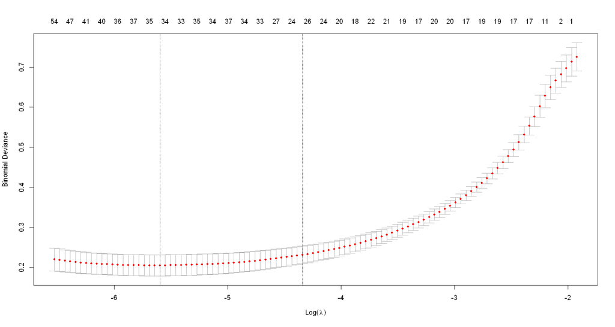

```r
classification_matrix = as.matrix(xyz_classification_train[,-c('from_class3'), with=F])
cv_logregfit = cv.glmnet(classification_matrix, xyz_classification_train$from_class3, family='binomial', type.measure='deviance')
plot(cv_logregfit)
```

```r
# shows the coeffs where lambda selected to be give the minumum binomial deviance, only head is showed due to so many number of features
head(coef(cv_logregfit, s="lambda.min"))
```

```
6 x 1 sparse Matrix of class "dgCMatrix"
                    1
(Intercept) -5.152533
X1           .
X2           .
X3           .
X4           .
X5           .
```

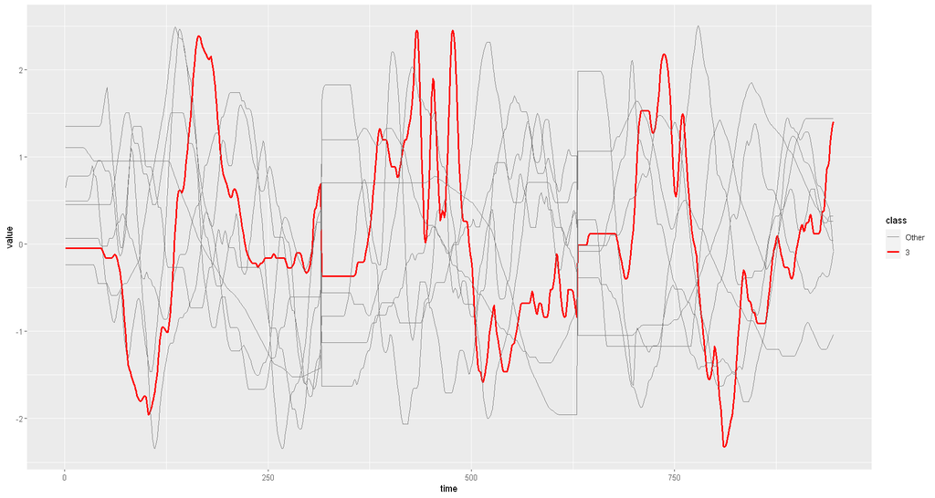

```r
# select sample from each class and plot all features as time series in order to find good indicator of class3
# and compare them with the ones obtained from the cv_logregfit above
samples = xyz_train[ , .SD[sample(x = .N, size = 1)], by = "class"]

# melt samples for long format
colnames(samples) = c("class", 1:945)
samples = melt(samples, id.vars=c('class'))
samples[,time:=as.numeric(variable)]
samples =samples[,list(class, time, value)]
samples = samples[order(class, time)]
ggplot(samples, aes(x=time, y=value)) + geom_line(aes(colour = class == "3", size = class == "3", group = class)) +
    scale_color_manual(name = "class", labels = c("Other", "3"), values = c("grey50", "red")) +
    scale_size_manual(name = "class", labels = c("Other", "3"), values = c(0.5, 1))
```

```r
classification_matrix_test = as.matrix(xyz_classification_test[,-c('from_class3'), with=F])
predicted_prob = predict(cv_logregfit, classification_matrix_test, s='lambda.min', type='response')
prediction = as.integer(predicted_prob > class3_ratio)
```

```r
# create confusion matrix and report accuracy
true_status = xyz_classification_test$from_class3
confusion_matrix = table(true_status, prediction)
confusion_matrix

accuracy = sum(true_status==prediction)/length(prediction)
print(accuracy)
```

```
           prediction
true_status    0    1
          0 2881  247
          1   31  423
```

```
[1] 0.9223897
```

###### Compared to first model, accuracy is increased significantly. This may due to using less & more important features

*b) Given this information, you are expected to transform your training data to distance information (i.e. N by N matrix). Note that you need to perform a similar transformation to your test data. In other words, you need to calculate the distance of each test instance to training instance to obtain a distance based representation for your test data. This will be an Ntest by N matrix (Ntest refers to the number of test instances) where each entry (i,j) refers to the distance of test time series i to the training time series j. You can use Euclidean distance as your distance measure.*

*Perform the same training and test strategy as in part b but use the distances as your new feature matrices. Comment on the regression coefficients. What do they imply under this new representation setting?*

```r
# calculate distances
dist_euc_train = as.matrix(dist(xyz_classification_train))
```

```r
head(dist_euc_train)
```

| 1 | 2 | 3 | 4 | 5 | 6 | 7 | 8 | 9 | 10 | ... | 887 | 888 | 889 | 890 | 891 | 892 | 893 | 894 | 895 | 896 |
| --- | --- | --- | --- | --- | --- | --- | --- | --- | --- | --- | --- | --- | --- | --- | --- | --- | --- | --- | --- | --- |
| 0.00000 | 51.30385 | 46.49263 | 50.01557 | 40.53065 | 48.77339 | 49.78434 | 34.47481 | 38.36707 | 30.47860 | ... | 46.01287 | 39.74289 | 41.26587 | 37.26560 | 52.64993 | 34.63176 | 40.36802 | 43.59052 | 47.17981 | 52.29014 |
| 51.30385 | 0.00000 | 26.15062 | 36.86113 | 32.71092 | 37.63036 | 38.19377 | 50.04145 | 37.77742 | 57.60482 | ... | 46.03559 | 49.02388 | 32.31978 | 49.04021 | 34.11599 | 44.41433 | 54.65286 | 41.24253 | 43.26349 | 24.41367 |
| 46.49263 | 26.15062 | 0.00000 | 43.12650 | 34.68557 | 34.77018 | 52.90127 | 45.07319 | 39.31871 | 54.02186 | ... | 49.77938 | 43.34457 | 34.88315 | 48.61401 | 36.60350 | 37.89300 | 49.85753 | 47.86957 | 52.75303 | 23.00783 |
| 50.01557 | 36.86113 | 43.12650 | 0.00000 | 45.10703 | 41.04296 | 39.73823 | 55.63393 | 49.69677 | 44.88470 | ... | 41.22758 | 38.46376 | 47.08175 | 44.04959 | 33.67063 | 43.62841 | 45.18424 | 36.48980 | 37.78595 | 37.75260 |
| 40.53065 | 32.71092 | 34.68557 | 45.10703 | 0.00000 | 36.55246 | 44.96919 | 34.49307 | 20.71561 | 48.63792 | ... | 47.36377 | 53.92067 | 17.27920 | 36.79339 | 49.61586 | 44.75503 | 44.68900 | 45.79881 | 44.43520 | 39.75526 |
| 48.77339 | 37.63036 | 34.77018 | 41.04296 | 36.55246 | 0.00000 | 48.51623 | 48.43767 | 42.56081 | 51.06056 | ... | 48.74836 | 52.97254 | 37.81844 | 42.26116 | 40.39066 | 46.15335 | 39.92165 | 43.24382 | 47.93611 | 32.42908 |

```r
# ensure that it is a N by N matrix
nrow(dist_euc_train)
```

896

```r
ncol(dist_euc_train)
```

896

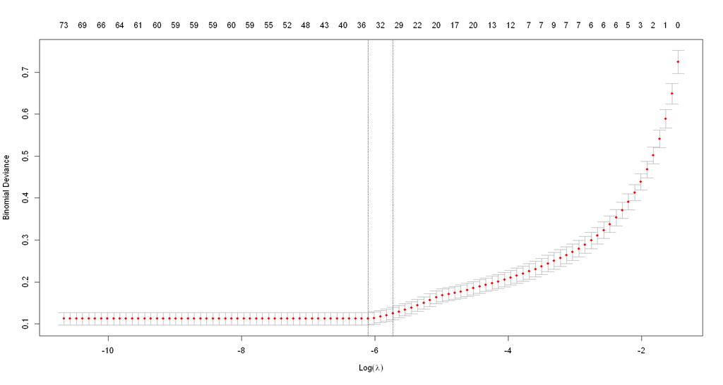

```r
distance_classification_matrix = as.matrix(dist_euc_train)
cv_distance_logregfit = cv.glmnet(distance_classification_matrix, xyz_classification_train$from_class3, family='binomial', type.measure='deviance')
plot(cv_distance_logregfit)
```

```r
# only head is showed due to so many number of features
head(coef(cv_distance_logregfit, s="lambda.min"))
```

```
6 x 1 sparse Matrix of class "dgCMatrix"
                      1
(Intercept) 47.70148271
1            .
2            .
3            .
4           -0.06759359
5            .
```

```r
require(pracma)
```

```r
distance_classification_matrix_test = distmat(as.matrix(xyz_classification_test[,-c('from_class3'), with=F]), as.matrix(xyz_classification_train[,-c('from_class3'), with=F]))
colnames(distance_classification_matrix_test) = 1:896
predicted_prob = predict(cv_distance_logregfit, distance_classification_matrix_test, s='lambda.min', type='response')
prediction = as.integer(predicted_prob > class3_ratio)
```

```r
head(distance_classification_matrix_test)
```

| 1 | 2 | 3 | 4 | 5 | 6 | 7 | 8 | 9 | 10 | ... | 887 | 888 | 889 | 890 | 891 | 892 | 893 | 894 | 895 | 896 |
| --- | --- | --- | --- | --- | --- | --- | --- | --- | --- | --- | --- | --- | --- | --- | --- | --- | --- | --- | --- | --- |
| 51.68756 | 13.26342 | 28.32155 | 39.54125 | 34.28679 | 38.21102 | 36.04586 | 48.76423 | 37.56808 | 59.42871 | ... | 44.36689 | 49.49473 | 32.77733 | 51.24089 | 35.25719 | 43.64244 | 51.73824 | 41.01137 | 41.87053 | 28.34948 |
| 34.94735 | 54.33434 | 54.69452 | 46.73249 | 45.80013 | 46.54591 | 41.58290 | 37.51753 | 46.17326 | 31.87027 | ... | 37.76089 | 42.29434 | 44.20783 | 38.80048 | 50.75335 | 42.98309 | 38.36250 | 44.87133 | 37.51762 | 55.64853 |
| 42.17192 | 25.57076 | 35.86093 | 42.16744 | 28.76008 | 37.98442 | 41.09122 | 44.31102 | 31.09547 | 50.16476 | ... | 46.95266 | 50.50451 | 30.28056 | 39.45372 | 45.69517 | 47.53898 | 50.38680 | 40.43990 | 43.68849 | 35.51105 |
| 41.87696 | 34.26903 | 41.88419 | 44.84055 | 25.51754 | 43.33635 | 38.77343 | 38.42295 | 20.20412 | 50.38129 | ... | 45.19798 | 53.93486 | 28.36898 | 42.63299 | 48.77538 | 49.69766 | 44.19728 | 42.86692 | 42.66795 | 41.61417 |
| 49.64224 | 14.39948 | 16.49077 | 41.30849 | 32.73789 | 37.11218 | 44.96458 | 47.15595 | 37.85653 | 57.15658 | ... | 47.80669 | 46.90974 | 32.78380 | 49.97981 | 34.79418 | 40.93229 | 53.61811 | 46.63892 | 47.71537 | 22.19925 |
| 46.34265 | 37.14210 | 42.45922 | 46.20299 | 32.04720 | 42.30269 | 36.86977 | 37.99367 | 33.19378 | 47.91947 | ... | 41.88324 | 51.99915 | 30.42622 | 38.74722 | 49.33934 | 45.97069 | 44.97836 | 38.11579 | 36.45461 | 43.07985 |

```r
# ensure that the distance matrix is a Ntest by N
nrow(distance_classification_matrix_test)
```

3582

```r
ncol(distance_classification_matrix_test)
```

896

```r
# create confusion matrix and report accuracy
true_status = xyz_classification_test$from_class3
confusion_matrix = table(true_status, prediction)
confusion_matrix

accuracy = sum(true_status==prediction)/length(prediction)
print(accuracy)
```

```
           prediction
true_status    0    1
          0 3010  118
          1   20  434
```

```
[1] 0.961474
```

*d) Provide an overall comparison on the results you obtain for each part (over all tasks). You can compare test accuracy of each alternative method you developed.*